# 在折線圖中比較趨勢

Tony Chuo, NSYSU

2022-03-19 15:34:01

🏠 **重點提要 :**  
■ 用折線圖來觀察趨勢  
■ 通過管道符號(pipeline)以連接 `dplyr` 和 `ggplot`  
■ 同時從各個面向比較趨勢

載入library裡面的套件並載入comics數據集

```r
pacman::p_load(dplyr,tidyr,ggplot2,plotly,gridExtra)
theme_set(theme_get() + theme(
  text=element_text(size=8), legend.key.size=unit(10,"points")
  ))
D = read.csv("data/comics1.csv",stringsAsFactors=F) %>% as_tibble
```

### 1. 簡單折線圖

讓我們計算並繪圖觀察每年首次亮相的新角色數量。

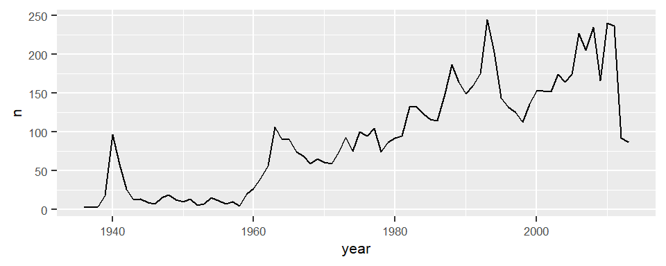

```r
count(D, year) %>%                    # 計算每年新角色的數量
  ggplot(aes(year, n)) + geom_line()  # 並繪製一個折線圖
```

`count()` 和 `ggplot() + geom_line()` 是一個非常方便的組合。我們可以通過一個額外的類別變數`publisher`來比較DC和Marvel每年新角色數量的的變化趨勢。

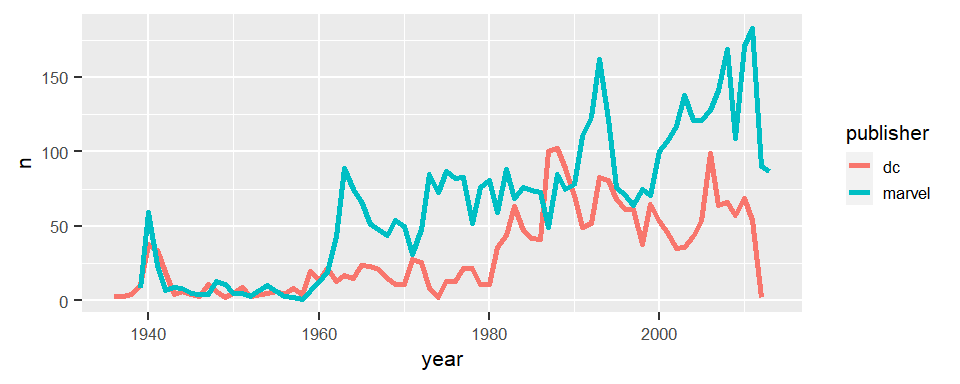

```r
count(D, year, publisher) %>%
  ggplot(aes(year, n, col=publisher)) +
  geom_line(size=1)
```

##### 1.1 消除波動的趨勢線

觀察長期趨勢的時候，如果趨勢線看起來波動太大，我們可以增加測量週期，資料合併通常有助於抵消隨機誤差，讓趨勢線變得比較平滑；由於DC在1980年之前不活躍，所以我們：

- 過濾掉1980年之前和2010年之後的數據
- 將30年分為6個期間(period)

```r
breaks=seq(1980,2010,5)
D2 = filter(D, year>=1980, year<=2010) %>%
  mutate(period = cut(year,breaks,breaks[-1],T) %>%
           as.character %>% as.integer)
table(D2$period, useNA='ifany')  # 納入缺失值
```

```
1985 1990 1995 2000 2005 2010
 690  763  926  659  817 1073
```

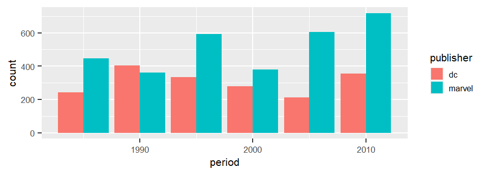

```r
ggplot(D2, aes(period, fill=publisher)) +
  geom_bar(position='dodge')
```

像這樣通過條狀圖來判斷長期趨勢要容易得多，不是嗎?

從上圖我們可以看到，漫畫產業在2000年經歷一個低谷之後，Marvel似乎比DC更早、更強勁地反彈回來。

### 2. 多方面比較趨勢

結合 `dplyr` 和 `ggplot`的強大功能，我們可以一次比較多個方面的趨勢。讓我們從一個簡單的圖開始，該圖視覺化了每個(好人/壞人/中立)陣營的比率如何變化。

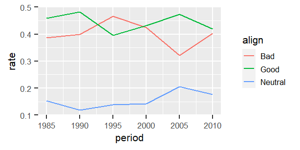

```r
count(D2, period, align) %>%
  group_by(period) %>%
  mutate(rate = n/sum(n)) %>%
  ggplot(aes(period, rate)) +
  geom_line(aes(col=align))
```

這一個趨勢是否因出版商而異呢？

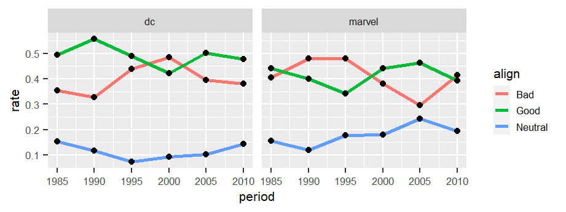

```r
count(D2, period, publisher, align) %>%  # 以類別型變數計算個數
  group_by(period, publisher) %>%        # 根據period和publisher來對資料進行分組
  mutate(rate = n/sum(n)) %>%            # 新增一個欄位rate並將計算的個數轉換為比率
  ggplot(aes(period, rate)) +
  facet_grid(~publisher) +               # 每一個出版商一個繪圖區塊(produce 1 panel per publisher)
  geom_line(aes(col=align), size=1) +    # 使線條更粗
  geom_point()                           # 增加圓點使其看起來更好
```

**🚴 **練習：****  
讓我們嘗試以出版商和性別來比較(好人/壞人/中立)陣營的趨勢。正如下面的圖表中看到的，在4個單獨的繪圖區塊中有4個模式(there’d be 4 patterns in 4 separate panels.)。你可以通過修改程式區塊來製作下面的圖表嗎？

```r
# count(D2, period, publisher, align) %>%
#   group_by(period, publisher) %>%
#   mutate(rate = n/sum(n)) %>%
#   ggplot(aes(period, rate)) +
#   facet_grid(sex~publisher) +            # 每一個繪圖區塊各一個出版商與性別(1 panel per publisher per sex)
#   geom_line(aes(col=align), size=1) +
#   geom_point()
```

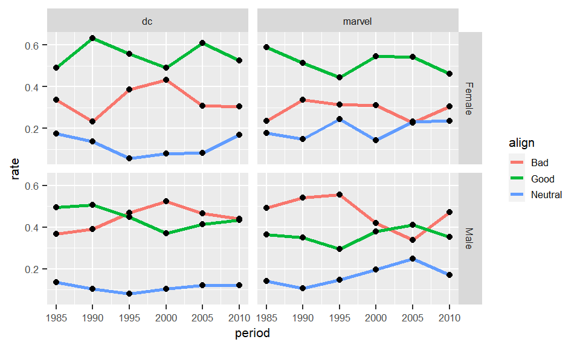

```r
count(D2, period, publisher, sex, align) %>%
  group_by(period, publisher, sex) %>%
  mutate(rate = n/sum(n)) %>%
  ggplot(aes(period, rate)) +
  facet_grid(sex~publisher) +
  geom_line(aes(col=align), size=1) +
  geom_point()
```